# Dog Project

Allyson Hafezi, Fiona Davoudi, and Jenna Hussein

2025-03-09

## Load the libraries

```r
library(tidyverse)
library(janitor)
library(naniar)
library("ggthemes")
library("RColorBrewer")
library("paletteer")
library(ggplot2)
```

## Organization of Project

Todo List

1. Clean Data
   - make nice names with underscores
   - remove $ and , and % from variables in dog_rankings
   - change chr to num variables when needed
   - clean shelter_dogs?/maybe pivot some columns in either dataset
2. Introduction - what is our research topic? List ideas below:
   - Making an App to choose a dog breed (dogs_ranking) and what are their traits, health situations. Combine with real shelter data on how many of that breed are typically available.
3. Methods - how will we analyze
   - make quiz shiny app so people can figure out what dog/dog breed fits their needs
   - create graphs showing notatble characteristics associated with popularity or that correlate with each other
4. Visuals - graphs, what are our key variables?
5. Conclusion - clear message
6. Organize Repository (going off the example given, but we can refine)
   - datasets folder
   - background info folder - need to check if we have any
   - shiny app folder
   - exploring data
   - graphs

## Read in the Data

“This data is a compilation of information on dogs who were available for adoption on December 12, 2019 in the Hungarian Database of Homeless Pets. In total, there were 2,937 dogs in the database. It contains information on dogs’ names, breed, color, age, sex, the date they were found, and some characteristics of their personalities.” [shelter_dogs](https://www.kaggle.com/datasets/jmolitoris/adoptable-dogs)

```r
shelter_dogs <- read_csv("datasets/ShelterDogs.csv") %>% clean_names()
```

“This dataset provides various attributes related to different dog breeds. Each row represents a specific breed and includes information on several characteristics, costs, and suitability aspects.” [dog_rankings](https://www.kaggle.com/datasets/jainaru/dog-breeds-ranking-best-to-worst)

```r
dog_rankings <- read_csv("datasets/dogs-ranking-dataset.csv") %>% clean_names
```

```
## ──────────────────────────────────────────────────────── Delimiter: "," chr
## (11): Breed, type, intelligence, congential ailments, size...9, $LIFETIM... dbl
## (8): score, popularity ranking, size...5, score for kids, INTELLIGENCE ...
```

## Evaluate Data

```r
glimpse(shelter_dogs)
```

```
## Rows: 2,937
## Columns: 19
## $ id                <dbl> 23807, 533, 23793, 23795, 23806, 23801, 534, 23805, …
## $ name              <chr> "Gida", "Frida És Ricsi", NA, NA, "Amy", "Alex", "Ri…
## $ age               <dbl> 0.25, 0.17, 4.00, 1.00, 2.00, 4.25, 0.17, 0.17, 0.17…
## $ sex               <chr> "female", "female", "male", "male", "female", "male"…
## $ breed             <chr> "Unknown Mix", "Unknown Mix", "Unknown Mix", "Unknow…
## $ date_found        <date> 2019-12-10, 2019-12-01, 2019-12-08, 2019-12-08, 201…
## $ adoptable_from    <date> 2019-12-11, 2019-12-01, 2019-12-23, 2019-12-23, 201…
## $ posted            <date> 2019-12-11, 2019-12-09, 2019-12-08, 2019-12-08, 201…
## $ color             <chr> "red", "black and white", "saddle back", "yellow-bro…
## $ coat              <chr> "short", "short", "short", "medium", "short", "short…
## $ size              <chr> "small", "small", "medium", "medium", "small", "smal…
## $ neutered          <chr> "no", "no", "no", "no", "no", "yes", "no", "no", "no…
## $ housebroken       <chr> NA, NA, NA, NA, NA, NA, NA, NA, NA, NA, NA, NA, NA, …
## $ likes_people      <chr> NA, "yes", NA, NA, NA, NA, "yes", NA, NA, "yes", NA,…
## $ likes_children    <chr> NA, "yes", NA, NA, NA, NA, "yes", NA, NA, "yes", NA,…
## $ get_along_males   <chr> NA, "yes", NA, NA, NA, NA, "yes", NA, NA, "yes", NA,…
## $ get_along_females <chr> NA, "yes", NA, NA, NA, NA, "yes", NA, NA, "yes", NA,…
## $ get_along_cats    <chr> NA, "yes", NA, NA, NA, NA, "yes", NA, NA, "yes", NA,…
## $ keep_in           <chr> NA, NA, NA, NA, NA, NA, NA, NA, NA, "flat", NA, NA, …
```

```r
glimpse(dog_rankings)
```

```
## Rows: 87
## Columns: 19
## $ breed                      <chr> "Border Terrier", "Cairn Terrier", "Siberia…
## $ type                       <chr> "terrier", "terrier", "working", "sporting"…
## $ score                      <dbl> 3.61, 3.53, 3.22, 3.34, 3.33, 3.30, 3.21, 3…
## $ popularity_ranking         <dbl> 61, 48, 16, 81, 51, 27, 50, 29, 20, 32, 30,…
## $ size_5                     <dbl> 1, 1, 2, 2, 2, 1, 1, 2, 1, 1, 2, 3, 3, 1, 2…
## $ intelligence               <chr> "Above average", "Above average", "Average"…
## $ congential_ailments        <chr> "none", "'lion jaw', heart problems", "none…
## $ score_for_kids             <dbl> 4.99, 4.91, 4.72, 4.71, 4.70, 4.67, 4.58, 4…
## $ size_9                     <chr> "small", "small", "medium", "medium", "medi…
## $ lifetime_cost              <chr> "$22,638", "$21,992", "$22,049", "$20,224",…
## $ intelligence_rank          <dbl> 30, 35, 45, 31, 18, 20, 68, 13, 6, 47, 19, …
## $ intelligence_percent       <chr> "70%", "61%", "45%", "69%", "82%", "79%", "…
## $ longevity_years            <dbl> 14.00, 13.84, 12.58, 12.49, 11.66, 12.50, 1…
## $ number_of_genetic_ailments <dbl> 0, 2, 0, 1, 0, 2, 1, 4, 5, 3, 0, 1, 1, 0, 3…
## $ genetic_ailments           <chr> "none", "'lion jaw', heart problems", "none…
## $ purchase_price             <chr> "$833", "$435", "$650", "$750", "$800", "$4…
## $ food_costs_per_year        <chr> "$324", "$324", "$466", "$324", "$324", "$6…
## $ grooming_frequncy          <chr> "Once a week", "Once a week", "Once in a fe…
## $ suitability_for_children   <dbl> 1, 1, 1, 1, 1, 1, 1, 1, 1, 1, 2, 1, 1, 1, 1…
```

## Data Cleaning - Fiona

```r
#change name of size_5 and size_9 column in dog_rankings
dog_rankings_c <- dog_rankings %>%
  rename(size_score=size_5) %>%
  rename(size_description=size_9)
```

```r
#remove $ or , or % from entries
dog_rankings_c <- dog_rankings_c %>%
  mutate(lifetime_cost = str_remove(lifetime_cost, ",")) %>%
  mutate(lifetime_cost = str_remove(lifetime_cost, "\\$")) %>%
  mutate(intelligence_percent = str_remove(intelligence_percent, "%")) %>%
  mutate(purchase_price = str_remove(purchase_price, "\\$")) %>%
  mutate(purchase_price = str_remove(purchase_price, ",")) %>%
  mutate(food_costs_per_year = str_remove(food_costs_per_year, "\\$")) %>%
  mutate(food_costs_per_year = str_remove(food_costs_per_year, ","))
```

```r
#convert chr to num
dog_rankings_c <- dog_rankings_c %>%
  mutate(lifetime_cost = as.numeric(lifetime_cost)) %>%
  mutate(intelligence_percent = as.numeric(intelligence_percent)) %>%
  mutate(purchase_price = as.numeric(purchase_price)) %>%
  mutate(food_costs_per_year = as.numeric(food_costs_per_year))

glimpse(dog_rankings_c)
```

```
## Rows: 87
## Columns: 19
## $ breed                      <chr> "Border Terrier", "Cairn Terrier", "Siberia…
## $ type                       <chr> "terrier", "terrier", "working", "sporting"…
## $ score                      <dbl> 3.61, 3.53, 3.22, 3.34, 3.33, 3.30, 3.21, 3…
## $ popularity_ranking         <dbl> 61, 48, 16, 81, 51, 27, 50, 29, 20, 32, 30,…
## $ size_score                 <dbl> 1, 1, 2, 2, 2, 1, 1, 2, 1, 1, 2, 3, 3, 1, 2…
## $ intelligence               <chr> "Above average", "Above average", "Average"…
## $ congential_ailments        <chr> "none", "'lion jaw', heart problems", "none…
## $ score_for_kids             <dbl> 4.99, 4.91, 4.72, 4.71, 4.70, 4.67, 4.58, 4…
## $ size_description           <chr> "small", "small", "medium", "medium", "medi…
## $ lifetime_cost              <dbl> 22638, 21992, 22049, 20224, 18993, 24330, 2…
## $ intelligence_rank          <dbl> 30, 35, 45, 31, 18, 20, 68, 13, 6, 47, 19, …
## $ intelligence_percent       <dbl> 70, 61, 45, 69, 82, 79, 15, 86, 94, 41, 80,…
## $ longevity_years            <dbl> 14.00, 13.84, 12.58, 12.49, 11.66, 12.50, 1…
## $ number_of_genetic_ailments <dbl> 0, 2, 0, 1, 0, 2, 1, 4, 5, 3, 0, 1, 1, 0, 3…
## $ genetic_ailments           <chr> "none", "'lion jaw', heart problems", "none…
## $ purchase_price             <dbl> 833, 435, 650, 750, 800, 465, 350, 615, 465…
## $ food_costs_per_year        <dbl> 324, 324, 466, 324, 324, 674, 324, 466, 405…
## $ grooming_frequncy          <chr> "Once a week", "Once a week", "Once in a fe…
## $ suitability_for_children   <dbl> 1, 1, 1, 1, 1, 1, 1, 1, 1, 1, 2, 1, 1, 1, 1…
```

```r
write.csv(dog_rankings_c, "datasets/dog_rankings_c", row.names = F)
```

## Fiona Data Exploration

```r
#popularity by type of dog
dog_rankings_c %>%
  group_by(type) %>%
  summarize(popularity = mean(popularity_ranking)) %>%
  arrange(desc(popularity))
```

```
## # A tibble: 7 × 2
##   type         popularity
##   <chr>             <dbl>
## 1 terrier            58.4
## 2 hound              52.7
## 3 sporting           46.1
## 4 herding            43.5
## 5 non-sporting       38.6
## 6 toy                36.8
## 7 working            32.3
```

Two type of scoring for family/kid friendly

1. score_for_kids: A rating indicating how suitable the breed is for families with children. Higher scores suggest greater suitability. Intelligence + longevity + ailments + cost scores (50% each) + 100% grooming score. highest possible score: 5
2. suitability_for_children: The suitability of the breed for families with children, typically measured on a scale (1 = high suitability, 2= medium suitability, 3= low suitability).

```r
#good for kids
dog_rankings_c %>%
  arrange(suitability_for_children) %>%
  select(breed, suitability_for_children, score_for_kids) %>%
  filter(score_for_kids >= 4.00) %>%
  arrange(-score_for_kids)
```

```
## # A tibble: 29 × 3
##    breed                       suitability_for_children score_for_kids
##    <chr>                                          <dbl>          <dbl>
##  1 Border Terrier                                     1           4.99
##  2 Cairn Terrier                                      1           4.91
##  3 Siberian Husky                                     1           4.72
##  4 Welsh Springer Spaniel                             1           4.71
##  5 English Cocker Spaniel                             1           4.7
##  6 Cocker Spaniel                                     1           4.67
##  7 Lhasa Apso                                         1           4.58
##  8 English Springer Spaniel                           1           4.47
##  9 Shetland Sheepdog                                  1           4.47
## 10 West Highland White Terrier                        1           4.45
## # ℹ 19 more rows
```

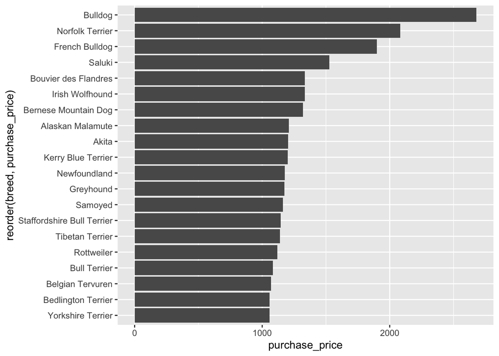

```r
#most expensive purchase dog
dog_rankings_c %>%
  select(breed, type, lifetime_cost, purchase_price, food_costs_per_year, grooming_frequncy) %>%
  slice_max(purchase_price, n=20) %>%
  ggplot(aes(x=reorder(breed, purchase_price), y=purchase_price))+
  geom_col()+
  coord_flip()
```

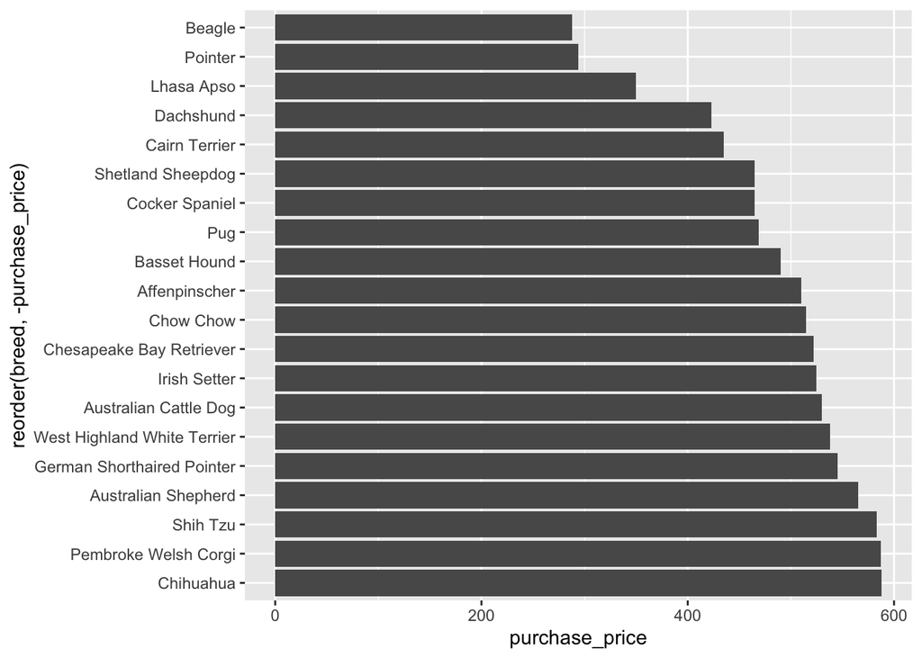

```r
#cheapest purchase dog
dog_rankings_c %>%
  select(breed, type, lifetime_cost, purchase_price, food_costs_per_year, grooming_frequncy) %>%
  slice_min(purchase_price, n=20) %>%
  ggplot(aes(x=reorder(breed, -purchase_price), y=purchase_price))+
  geom_col()+
  coord_flip()
```

```r
#most common breed in shelter
shelter_dogs %>%
  count(breed) %>%
  arrange(desc(n))
```

```
## # A tibble: 277 × 2
##    breed                         n
##    <chr>                     <int>
##  1 Unknown Mix                1524
##  2 German Shepherd Dog Mix     190
##  3 Dachshund Mix               147
##  4 Labrador Retriever Mix       83
##  5 Staffordshire Terrier Mix    62
##  6 Puli Mix                     40
##  7 German Shepherd Dog          37
##  8 Schnauzer Mix                34
##  9 Fox Terrier Mix              32
## 10 Greyhound Mix                32
## # ℹ 267 more rows
```

## Allyson Data Exploration

```r
dog_rankings_c
```

```
## # A tibble: 87 × 19
##    breed                  type  score popularity_ranking size_score intelligence
##    <chr>                  <chr> <dbl>              <dbl>      <dbl> <chr>
##  1 Border Terrier         terr…  3.61                 61          1 Above avera…
##  2 Cairn Terrier          terr…  3.53                 48          1 Above avera…
##  3 Siberian Husky         work…  3.22                 16          2 Average
##  4 Welsh Springer Spaniel spor…  3.34                 81          2 Above avera…
##  5 English Cocker Spaniel spor…  3.33                 51          2 Excellent
##  6 Cocker Spaniel         spor…  3.3                  27          1 Excellent
##  7 Lhasa Apso             non-…  3.21                 50          1 Fair
##  8 English Springer Span… spor…  3.09                 29          2 Excellent
##  9 Shetland Sheepdog      herd…  3.22                 20          1 Brightest
## 10 West Highland White T… terr…  3.08                 32          1 Average
## # ℹ 77 more rows
## # ℹ 13 more variables: congential_ailments <chr>, score_for_kids <dbl>,
## #   size_description <chr>, lifetime_cost <dbl>, intelligence_rank <dbl>,
## #   intelligence_percent <dbl>, longevity_years <dbl>,
## #   number_of_genetic_ailments <dbl>, genetic_ailments <chr>,
## #   purchase_price <dbl>, food_costs_per_year <dbl>, grooming_frequncy <chr>,
## #   suitability_for_children <dbl>
```

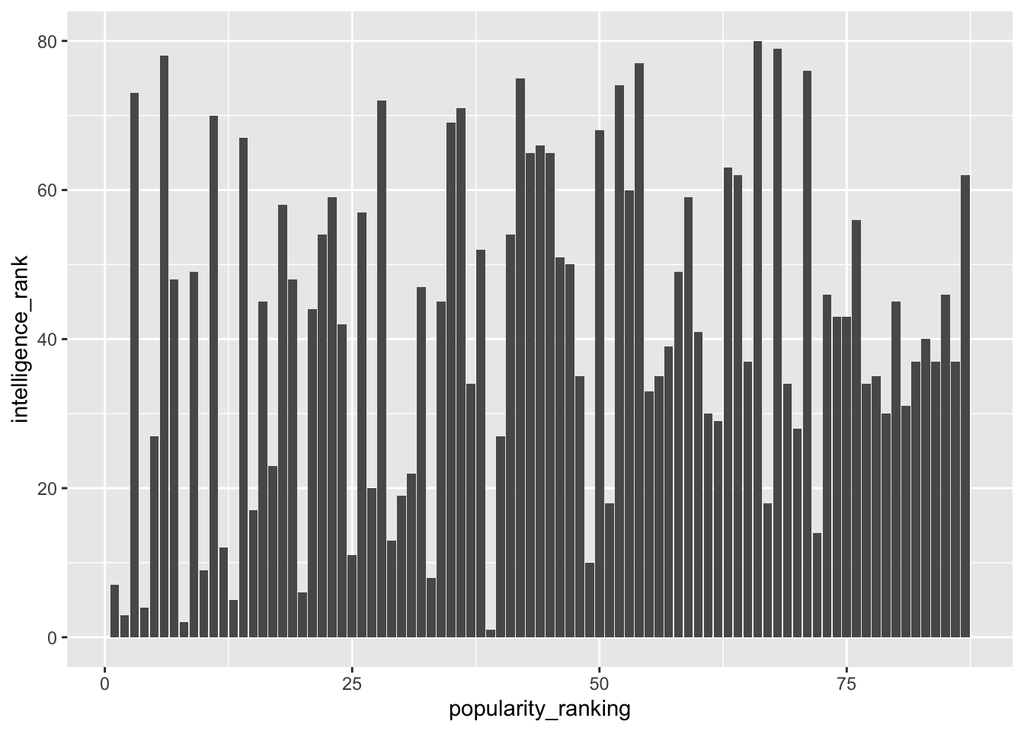

```r
#Graphs for the Presentation
  # 1) Is popularity determined by breed intelligence?
dog_rankings_c %>%
  ggplot(aes(x=popularity_ranking, y=intelligence_rank))+
  geom_col()
```

```r
#No correlation, popular dogs have no correlation with intelligence
```

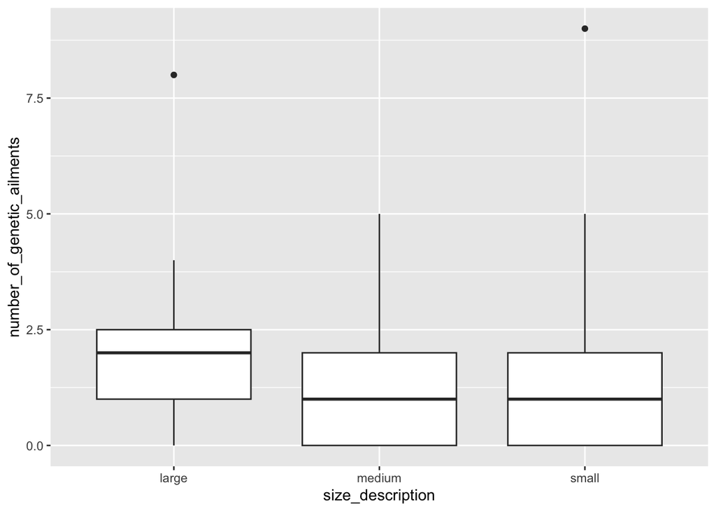

```r
# 2) Does breed size (smaller or larger dogs) correlate with number of genetic aliments?
dog_rankings_c %>%
  ggplot(aes(x=size_description, y=number_of_genetic_ailments))+
  geom_boxplot()
```

```r
#No correlation
```

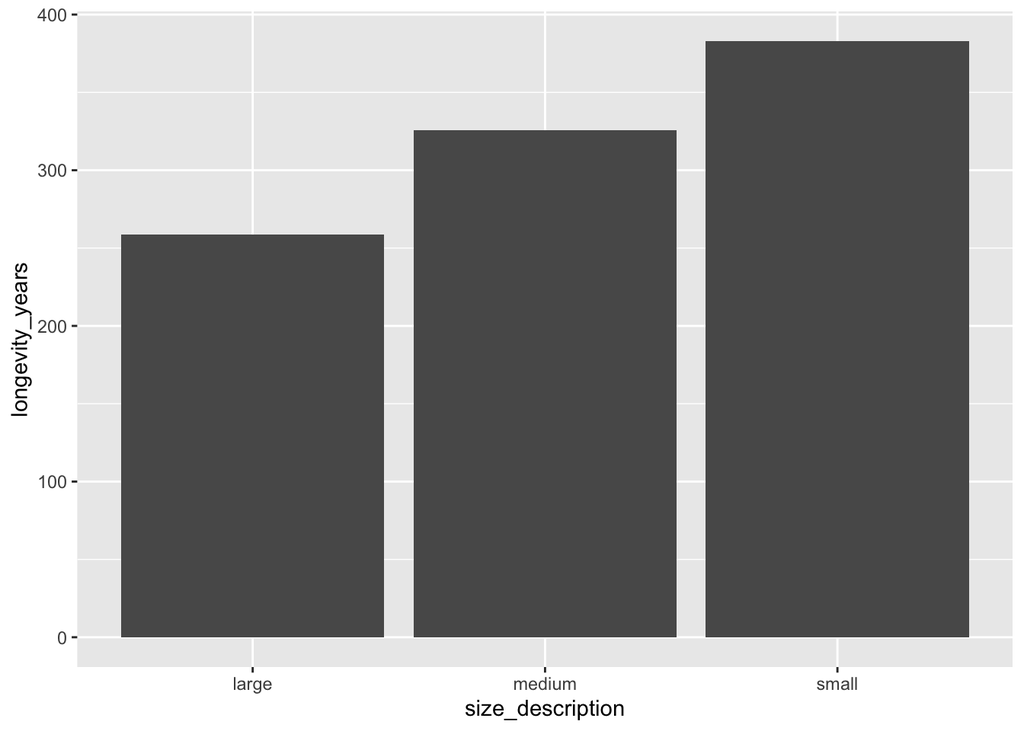

```r
# 3) Is there a correlation between size and longevity? Do smaller dogs live longer according to this data?
dog_rankings_c %>%
  ggplot(aes(x=size_description, y=longevity_years))+
  geom_col()
```

```r
#There is a correlation! Small dogs live longer!
```

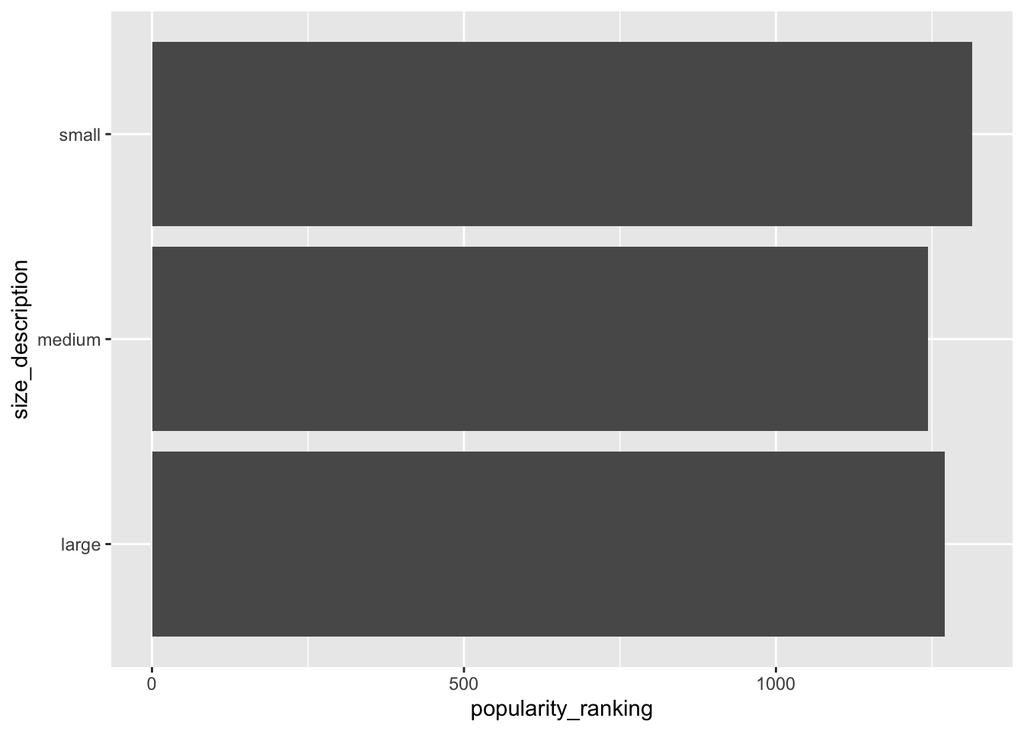

```r
# 4) Do small dogs tend to be more popular?
dog_rankings_c %>%
  ggplot(aes(x=popularity_ranking, y=size_description))+
  geom_col()
```

## Jenna Data Exploration

```r
summary(shelter_dogs)
```

```
##        id            name                age            sex
##  Min.   :    1   Length:2937        Min.   : 0.15   Length:2937
##  1st Qu.:  167   Class :character   1st Qu.: 5.83   Class :character
##  Median :  556   Mode  :character   Median : 8.67   Mode  :character
##  Mean   : 1743                      Mean   : 8.57
##  3rd Qu.: 1451                      3rd Qu.:11.25
##  Max.   :23809                      Max.   :21.92
##     breed             date_found         adoptable_from
##  Length:2937        Min.   :2001-04-01   Min.   :2001-04-01
##  Class :character   1st Qu.:2011-05-01   1st Qu.:2011-06-02
##  Mode  :character   Median :2013-09-10   Median :2013-09-26
##                     Mean   :2013-12-05   Mean   :2013-12-19
##                     3rd Qu.:2016-05-12   3rd Qu.:2016-05-15
##                     Max.   :2019-12-11   Max.   :2020-01-01
##      posted              color               coat               size
##  Min.   :2005-05-02   Length:2937        Length:2937        Length:2937
##  1st Qu.:2012-03-21   Class :character   Class :character   Class :character
##  Median :2014-01-09   Mode  :character   Mode  :character   Mode  :character
##  Mean   :2014-07-13
##  3rd Qu.:2016-11-27
##  Max.   :2019-12-12
##    neutered         housebroken        likes_people       likes_children
##  Length:2937        Length:2937        Length:2937        Length:2937
##  Class :character   Class :character   Class :character   Class :character
##  Mode  :character   Mode  :character   Mode  :character   Mode  :character
##
##
##
##  get_along_males    get_along_females  get_along_cats       keep_in
##  Length:2937        Length:2937        Length:2937        Length:2937
##  Class :character   Class :character   Class :character   Class :character
##  Mode  :character   Mode  :character   Mode  :character   Mode  :character
##
##
##
```

```r
#number of male and female dogs
shelter_dogs %>%
  select(sex, breed) %>%
  count(sex)
```

```
## # A tibble: 2 × 2
##   sex        n
##   <chr>  <int>
## 1 female  1256
## 2 male    1681
```

```r
#breeds in the shelter
shelter_dogs %>%
  filter(breed != "Adoptable From:", breed != "Unknown Mix") %>%
  count(breed) %>%
  arrange(-n)
```

```
## # A tibble: 275 × 2
##    breed                         n
##    <chr>                     <int>
##  1 German Shepherd Dog Mix     190
##  2 Dachshund Mix               147
##  3 Labrador Retriever Mix       83
##  4 Staffordshire Terrier Mix    62
##  5 Puli Mix                     40
##  6 German Shepherd Dog          37
##  7 Schnauzer Mix                34
##  8 Fox Terrier Mix              32
##  9 Greyhound Mix                32
## 10 Terrier Mix                  29
## # ℹ 265 more rows
```

```r
#different breeds of SMALL dogs in the shelter waiting to be adopted
small_breeds <- shelter_dogs %>%
  select(breed, size) %>%
  filter(breed != "Unknown Mix", size == "small") %>%
  count(breed) %>%
  arrange(-n)
small_breeds
```

```
## # A tibble: 75 × 2
##    breed                        n
##    <chr>                    <int>
##  1 Dachshund Mix              115
##  2 Fox Terrier Mix             15
##  3 Terrier Mix                  8
##  4 Pekingese Mix                7
##  5 Pinscher Mix                 7
##  6 Miniature Schnauzer Mix      5
##  7 Schnauzer Mix                5
##  8 Dachshund, Pekingese Mix     4
##  9 Puli Mix                     4
## 10 Dachshund                    3
## # ℹ 65 more rows
```

```r
#different breeds of MEDIUM dogs in the shelter waiting to be adopted
medium_breeds <- shelter_dogs %>%
  select(breed, size) %>%
  filter(breed != "Unknown Mix", size == "medium") %>%
  count(breed) %>%
  arrange(-n)
medium_breeds
```

```
## # A tibble: 185 × 2
##    breed                         n
##    <chr>                     <int>
##  1 German Shepherd Dog Mix     116
##  2 Staffordshire Terrier Mix    57
##  3 Labrador Retriever Mix       53
##  4 Puli Mix                     34
##  5 Dachshund Mix                32
##  6 Greyhound Mix                28
##  7 Schnauzer Mix                25
##  8 Terrier Mix                  19
##  9 Vizsla Mix                   18
## 10 Fox Terrier Mix              17
## # ℹ 175 more rows
```

```r
#different breeds of LARGE dogs in the shelter waiting to be adopted
large_breeds <- shelter_dogs %>%
  select(breed, size) %>%
  filter(breed != "Unknown Mix", breed != "Adoptable From:", size == "large") %>%
  count(breed) %>%
  arrange(-n)
large_breeds
```

```
## # A tibble: 93 × 2
##    breed                       n
##    <chr>                   <int>
##  1 German Shepherd Dog Mix    73
##  2 Labrador Retriever Mix     28
##  3 German Shepherd Dog        21
##  4 Labrador Retriever         13
##  5 Rottweiler Mix             13
##  6 Hound Mix                   7
##  7 Dogo Argentino              6
##  8 Vizsla Mix                  6
##  9 Cane Corso Mix              5
## 10 Caucasian Ovtcharka Mix     5
## # ℹ 83 more rows
```

```r
dog_rankings %>%
  count(type)
```

```
## # A tibble: 7 × 2
##   type             n
##   <chr>        <int>
## 1 herding         10
## 2 hound           13
## 3 non-sporting    10
## 4 sporting        15
## 5 terrier         12
## 6 toy             13
## 7 working         14
```

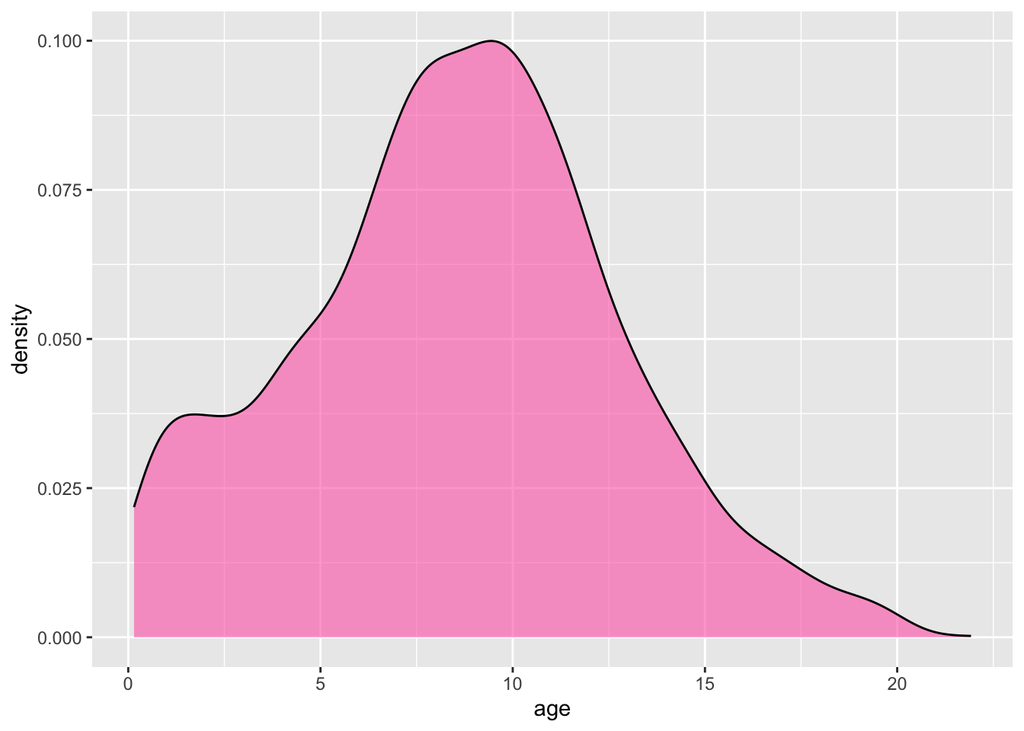

```r
#age distribution
shelter_dogs %>%
  ggplot(aes(x = age))+
  geom_density(color = 'black', fill = 'hotpink', alpha = 0.6)
```

##Notable Graphs for Presentation Visuals

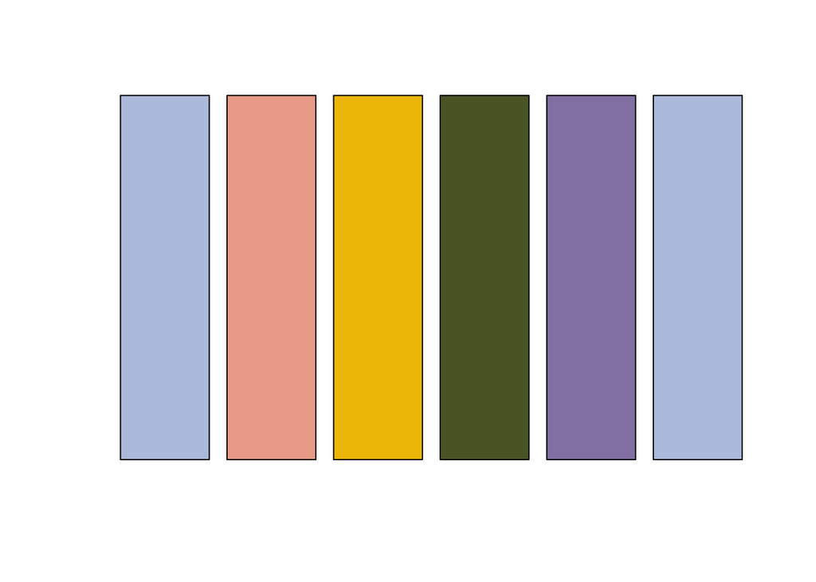

```r
#theme and colors
colors <- paletteer::palettes_d_names
my_palette <- paletteer_d("calecopal::superbloom1")
barplot(rep(1,6), axes=FALSE, col=my_palette)
```

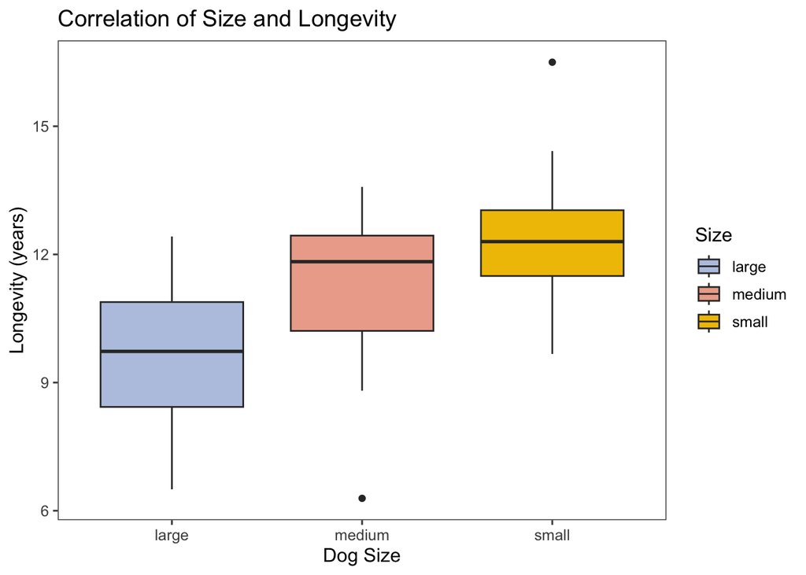

```r
#size and longevity correlation
dog_rankings_c %>%
  ggplot(aes(x=size_description, y=longevity_years, fill = size_description))+
  geom_boxplot()+
  labs(title = "Correlation of Size and Longevity",
       x = "Dog Size",
       y = "Longevity (years)",
       fill = "Size")+
  theme_few()+
  scale_fill_manual(values=my_palette)
```

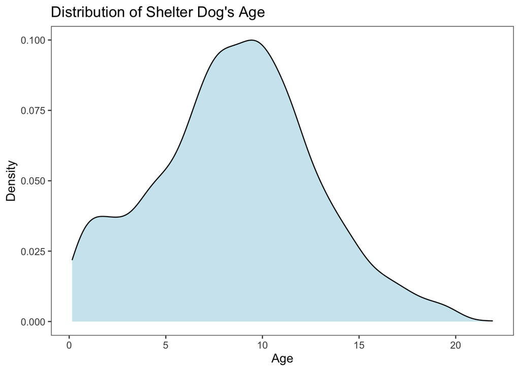

```r
#age distribution
shelter_dogs %>%
  ggplot(aes(x = age))+
  geom_density(color = 'black', fill = 'lightblue', alpha = 0.6)+
  labs(title = "Distribution of Shelter Dog's Age",
       x = "Age",
       y = "Density")+
  theme_few()+
  scale_fill_manual(values=my_palette)
```

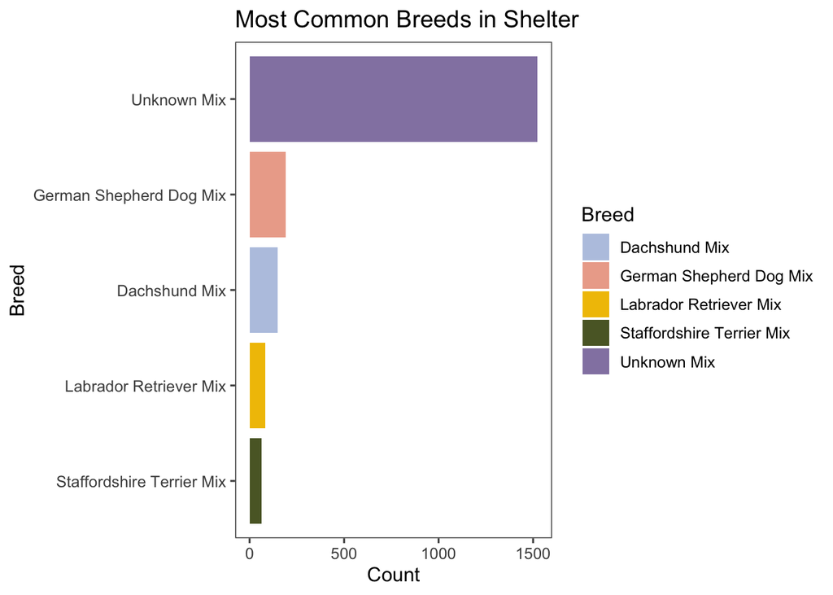

```r
#most common breed in shelter
shelter_dogs %>%
  count(breed) %>%
  slice_max(n, n = 5) %>%
  ggplot(aes(x = reorder(breed, n), y = n, fill = breed)) +
  geom_bar(stat = "identity")+
  coord_flip()+
  labs(title = "Most Common Breeds in Shelter",
       x= "Breed",
       y= "Count",
       fill = "Breed")+
  theme_few()+
  scale_fill_manual(values=my_palette)
```

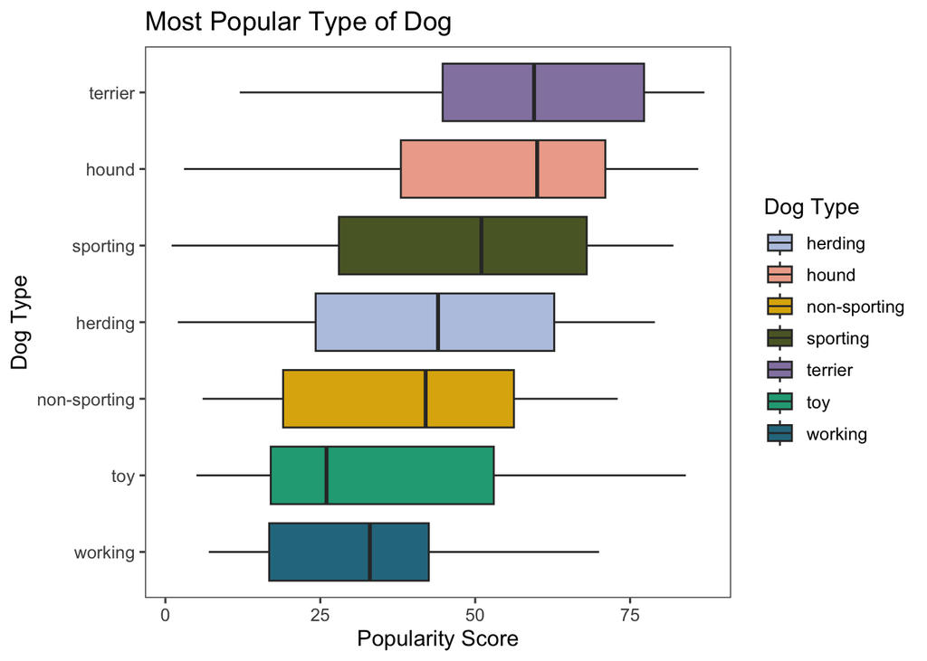

```r
my_extended_palette <- c("#b9c7e2", "#edab99", "#ddb109", "#5b6530", "#9484b0", "#22A884", "#2A788E", "#FBAE17")

dog_rankings_c %>%
  ggplot(aes(x = reorder(type, popularity_ranking), y = popularity_ranking, fill = type))+
  geom_boxplot()+
  coord_flip()+
  labs(title = "Most Popular Type of Dog",
       x= "Dog Type",
       y= "Popularity Score",
       fill = "Dog Type")+
  theme_few()+
  scale_fill_manual(values=my_extended_palette)
```

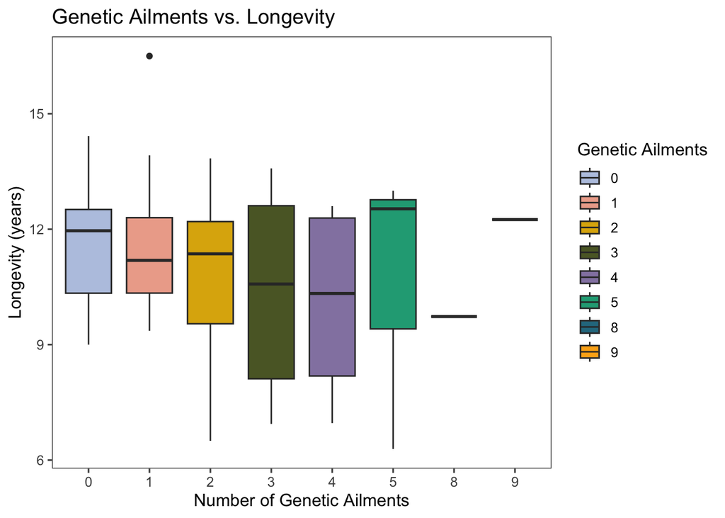

```r
dog_rankings_c %>%
  ggplot(aes(x=as.factor(number_of_genetic_ailments), y=longevity_years, fill=as.factor(number_of_genetic_ailments)))+
  geom_boxplot()+
  labs(title = "Genetic Ailments vs. Longevity",
       x= "Number of Genetic Ailments",
       y= "Longevity (years)",
       fill = "Genetic Ailments")+
  theme_few()+
  scale_fill_manual(values=my_extended_palette)
```

##Shelter Dogs Shiny App - Allyson Hafezi

```r
library(shiny)
library(shinythemes)
library(tidyverse)

# Load dataset
dog_data <- read_csv("datasets/ShelterDogs.csv")
ui <- fluidPage(
  theme = shinytheme("cerulean"),
  tags$head(tags$style(HTML("
    body { background-color: #f0f8ff; }
    .title-panel { text-align: center; padding: 20px; }
    .panel-box {
      background: #ffffff;
      padding: 20px;
      border-radius: 10px;
      box-shadow: 0 2px 10px rgba(0,0,0,0.1);
      margin: 20px auto;
      max-width: 800px;
    }
    h1, h3, label { color: #333333; }
    .btn-primary { background-color: #ff6b6b; border-color: #ff6b6b; }
    .btn-primary:hover { background-color: #ff4757; border-color: #ff4757; }
    .dog-card {
      background: #fff;
      padding: 15px;
      margin-bottom: 15px;
      border-radius: 8px;
      box-shadow: 0 2px 5px rgba(0,0,0,0.1);
    }
  "))),
  div(class = "title-panel", h1("🐶 Find Your Perfect Dog! 🐾")),

  # Row for all questions (displayed on one panel at the top)
  fluidRow(
    column(12,
           div(class = "panel-box",
               h3("Tell us about your ideal dog!"),
               selectInput("size", "Preferred Dog Size:",
                           choices = c("Not Important", unique(dog_data$size))),
               selectInput("coat", "Preferred Coat Type:",
                           choices = c("Not Important", unique(dog_data$coat))),
               selectInput("coat_color", "What coat color do you prefer?",
                           choices = c("Not Important", unique(dog_data$color))),
               selectInput("sex", "Preferred Sex:",
                           choices = c("Not Important", unique(dog_data$sex))),
               sliderInput("age", "Preferred Age Range:",
                           min = floor(min(dog_data$age, na.rm = TRUE)),
                           max = ceiling(max(dog_data$age, na.rm = TRUE)),
                           value = c(floor(min(dog_data$age, na.rm = TRUE)),
                                     ceiling(max(dog_data$age, na.rm = TRUE))),
                           step = 1),
               selectInput("good_with_kids", "Good with children?",
                           choices = c("Not Important", "yes")),
               selectInput("good_with_males", "Good with male dogs?",
                           choices = c("Not Important", "yes")),
               selectInput("good_with_females", "Good with female dogs?",
                           choices = c("Not Important", "yes")),
               selectInput("good_with_cats", "Good with cats?",
                           choices = c("Not Important", "yes")),
               selectInput("house_trained", "House Trained?",
                           choices = c("Not Important", "yes")),
               selectInput("neutered", "Neutered?",
                           choices = c("Not Important", "yes", "no")),
               br(),
               actionButton("find", "🐾 Find My Dog!", class = "btn-primary btn-lg")
           )
    )
  ),

  # Row for the results (displayed below the questions)
  fluidRow(
    column(12,
           div(class = "panel-box",
               h3("Your Best Matches:"),
               h4(textOutput("num_results")),
               uiOutput("results")
           )
    )
  )
)

server <- function(input, output, session) {

  filtered_data <- eventReactive(input$find, {
    df <- dog_data
    if (input$size != "Not Important") {
      df <- df %>% filter(size == input$size)
    }
    if (input$coat != "Not Important") {
      df <- df %>% filter(coat == input$coat)
    }
    if (input$coat_color != "Not Important") {
      df <- df %>% filter(color == input$coat_color)
    }
    if (input$sex != "Not Important") {
      df <- df %>% filter(sex == input$sex)
    }
    df <- df %>% filter(age >= input$age[1] & age <= input$age[2])
    if (input$good_with_kids == "yes") {
      df <- df %>% filter(likes_children == "yes")
    }
    if (input$good_with_males == "yes") {
      df <- df %>% filter(get_along_males == "yes")
    }
    if (input$good_with_females == "yes") {
      df <- df %>% filter(get_along_females == "yes")
    }
    if (input$good_with_cats == "yes") {
      df <- df %>% filter(get_along_cats == "yes")
    }
    if (input$house_trained == "yes") {
      df <- df %>% filter(housebroken == "yes")
    }
    if (input$neutered != "Not Important") {
      df <- df %>% filter(neutered == input$neutered)
    }
    df
  })

  output$num_results <- renderText({
    paste("Number of Matches:", nrow(filtered_data()))
  })

  output$results <- renderUI({
    df <- filtered_data()
    if (nrow(df) == 0) {
      return(h4("No matches found! Try adjusting your preferences.",
                style = "color: red; text-align: center;"))
    }
    lapply(1:nrow(df), function(i) {
      div(class = "dog-card",
          h4(df$name[i], style = "color: #ff6b6b;"),
          p(strong("Breed:"), df$breed[i]),
          p(strong("Sex:"), df$sex[i]),
          p(strong("Size:"), df$size[i]),
          p(strong("Age:"), df$age[i], "years"),
          p(strong("Coat:"), df$coat[i]),
          p(strong("Coat Color:"), df$color[i])
      )
    })
  })
}

shinyApp(ui = ui, server = server)
```

Shiny applications not supported in static R Markdown documents

# #Dog Rankings Shiny App - Jenna Hussein

##Shiny App Dog Rankings - Jenna Hussein

```r
library(shiny)
library(shinythemes)


dog_data <- read.csv("datasets/dog_rankings_c.csv")

ui <- fluidPage(
   theme = shinytheme("sandstone"),
  div(class = "title-panel", h1("🐶 Find Your Perfect Dog! 🐾", style = "color: #ff6b6b;")),
  sidebarLayout(
    sidebarPanel(
      class = "sidebar-panel",

      # Dog type selection
      selectInput("dog_type", "Dog Type:",
                  choices = c("Any", unique(dog_data$type))),

      # Intelligence selection
      selectInput("intelligence", "Intelligence Level:",
                  choices = c("Any", "Above average", "Average", "Excellent", "Fair", "Brightest", "Lowest")),

      # Size description selection
      selectInput("size_descriptions", "Size Description:",
                  choices = c("Any", "small", "medium", "large")),

      # Longevity slider
      sliderInput("longevity", "Longevity (years):",
                  min = 9, max = 17, value = c(9, 17), step = 1),

      # Grooming frequency selection
      selectInput("grooming_frequency", "Grooming Frequency:",
                  choices = c("Any", unique(dog_data$grooming_frequncy))),

      # Breed selection
      selectInput("breed", "Breed:", choices = c("Any", unique(dog_data$breed))),

      br(),
      actionButton("find", "🐾 Find My Dog!", class = "btn-primary btn-lg"),
      actionButton("reset", "🔄 Reset Choices", class = "btn-warning btn-lg")  # Reset button
    ),
    mainPanel(
      class = "main-panel",
      h3("🐕 Your Best Matches:"),
      h4(textOutput("num_results"), style = "color: #333333; text-align: center;"),
      uiOutput("results"),
      h3("🐾 Dog Rankings:", style = "margin-top: 30px;"),
      tableOutput("rankings_table")
    )
  )
)

server <- function(input, output, session) {
  # Function to reset inputs to default values
  observeEvent(input$reset, {
    updateSelectInput(session, "dog_type", selected = "Any")
    updateSelectInput(session, "intelligence", selected = "Any")
    updateSelectInput(session, "size_descriptions", selected = "Any")
    updateSliderInput(session, "longevity", value = c(9, 17))
    updateSelectInput(session, "grooming_frequency", selected = "Any")
    updateSelectInput(session, "breed", selected = "Any")
  })

  filtered_data <- eventReactive(input$find, {
    df <- dog_data

    # Filter based on dog type
    if (input$dog_type != "Any") {
      df <- df[tolower(df$type) == tolower(input$dog_type),]
    }

    # Filter based on intelligence level
    if (input$intelligence != "Any") {
      df <- df[tolower(df$intelligence) == tolower(input$intelligence),]
    }

    # Filter based on size descriptions
    if (input$size_descriptions != "Any") {
      df <- df[tolower(df$size_descriptions) == tolower(input$size_descriptions),]
    }

    # Filter based on longevity range
    df <- df[df$longevity_years >= input$longevity[1] & df$longevity_years <= input$longevity[2],]

    # Filter based on grooming frequency (correct spelling)
    if (input$grooming_frequency != "Any") {
      df <- df[tolower(trimws(df$grooming_frequncy)) == tolower(trimws(input$grooming_frequency)),]
    }

    # Filter based on breed
    if (input$breed != "Any") {
      df <- df[tolower(df$breed) == tolower(input$breed),]
    }

    # Add RowID column for unique ID
    df$RowID <- seq_along(df$breed)  # Add unique RowID based on the row index

    df
  })

  # Display the number of results
  output$num_results <- renderText({
    paste("Number of Matches:", nrow(filtered_data()))
  })

  # Render the list of dog matches with their unique IDs
  output$results <- renderUI({
    dog_list <- filtered_data()
    if (nrow(dog_list) == 0) {
      return(h4("No matches found! Try adjusting your preferences.", style = "color: red; text-align: center;"))
    }
    dog_ui <- lapply(1:nrow(dog_list), function(i) {
      dog <- dog_list[i, ]
      # Display dog information along with a unique ID
      div(class = "dog-card",
          h4(dog$name, style = "color: #ff6b6b;"),
          p(strong("Breed:"), dog$breed),
          p(strong("Size:"), dog$size_descriptions),
          p(strong("Dog Type:"), dog$type),  # Display dog type
          p(strong("Intelligence Level:"), dog$intelligence),
          p(strong("Longevity:"), dog$longevity_years, "years"),
          p(strong("Grooming Frequency:"), dog$grooming_frequncy),
          # Display unique ID for each dog
          p(strong("Unique ID:"), dog$RowID),  # Show RowID
          p("Scroll through the dog rankings table below and find the dog with this Unique ID.")
      )
    })
    do.call(tagList, dog_ui)
  })

  # Render the full dog rankings table (unfiltered) with unique IDs
  output$rankings_table <- renderTable({
    df <- dog_data
    df$RowID <- seq_along(df$breed)  # Add RowID column for unique ID in the rankings table
    df
  }, striped = TRUE, hover = TRUE, bordered = TRUE, rownames = TRUE, escape = FALSE)
}
shinyApp(ui, server)
```

Shiny applications not supported in static R Markdown documents